# Notes and activity: Logistic regression

### Part 4: Visualizing the best-performing candidate model itself: Plot the logistic curve

```r
# The logistic curve's X-axis
candidate2$linear.predictors
```

[output not shown]

[output cut: 173 more lines]

[output not shown]

```r
# The logistic curve's Y-axis (see how these are all between 0-1?)
candidate2$fitted.values
```

[output not shown]

[output cut: 141 more lines]

[output not shown]

```r
range(candidate2$fitted.values)
```

```
## [1] 0.02379126 0.99999980
```

```r
# Make a tibble and plot it up:
tibble(logistic_x = candidate2$linear.predictors,
       logistic_y = candidate2$fitted.values,
       truth = biopsy_01$outcome) -> logistic_model_plot_data

logistic_model_plot_data
```

```
## # A tibble: 683 × 3
##    logistic_x logistic_y truth
##         <dbl>      <dbl> <dbl>
##  1     -3.71      0.0238     0
##  2      0.930     0.717      0
##  3     -3.71      0.0238     0
##  4      7.12      0.999      0
##  5     -3.71      0.0238     0
##  6     10.2       1.00       1
##  7     -3.71      0.0238     0
##  8     -3.71      0.0238     0
##  9     -1.41      0.196      0
## 10     -2.17      0.103      0
## # … with 673 more rows
```

```r
# but wait, that truth column :(
# Make tibble with INFORMATIVE truth column for COMMUNICATING WITH DATA VIZ!
tibble(logistic_x = candidate2$linear.predictors,
       logistic_y = candidate2$fitted.values,
       truth = if_else(biopsy_01$outcome == 1, "Malignant", "Benign")) -> logistic_model_plot_data

# much better!
logistic_model_plot_data
```

```
## # A tibble: 683 × 3
##    logistic_x logistic_y truth
##         <dbl>      <dbl> <chr>
##  1     -3.71      0.0238 Benign
##  2      0.930     0.717  Benign
##  3     -3.71      0.0238 Benign
##  4      7.12      0.999  Benign
##  5     -3.71      0.0238 Benign
##  6     10.2       1.00   Malignant
##  7     -3.71      0.0238 Benign
##  8     -3.71      0.0238 Benign
##  9     -1.41      0.196  Benign
## 10     -2.17      0.103  Benign
## # … with 673 more rows
```

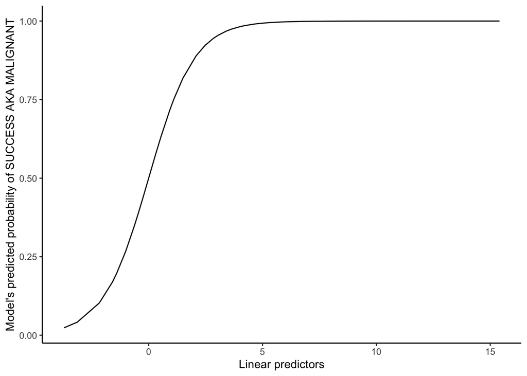

```r
# The curve alone with `geom_line()`:
ggplot(logistic_model_plot_data) +
  aes(x = logistic_x,
      y = logistic_y) +
  geom_line() +
  labs(x = "Linear predictors",
       y = "Model's predicted probability of SUCCESS AKA MALIGNANT")
```

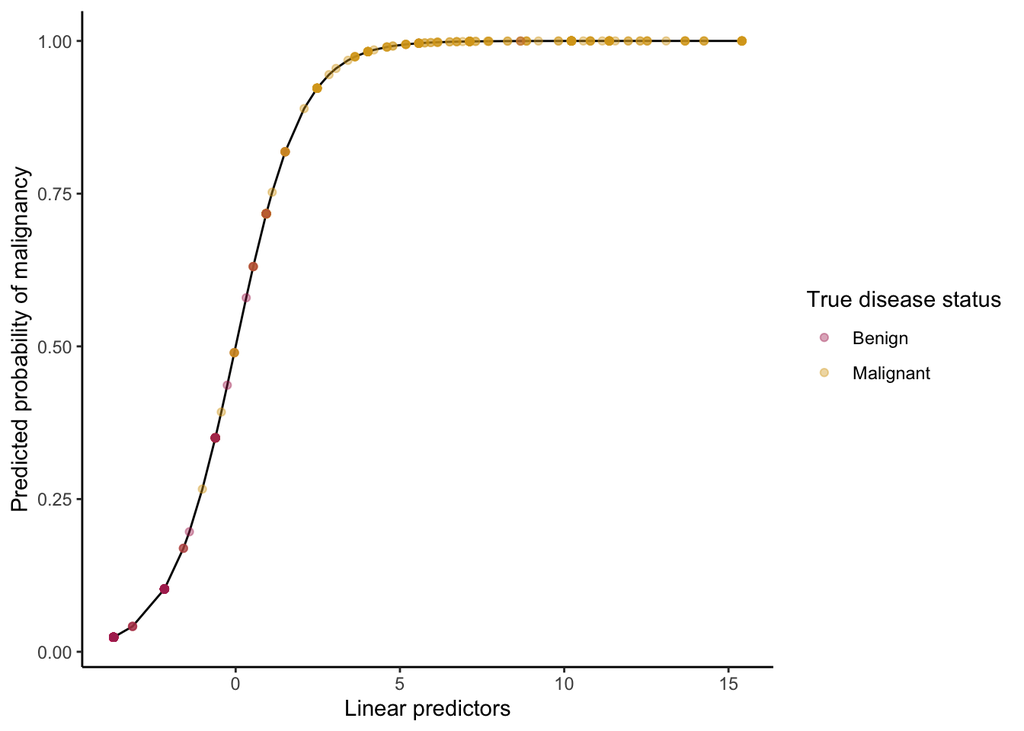

```r
# The curve with THE TRUE OUTCOMES added in (HW11!!)
ggplot(logistic_model_plot_data) +
  aes(x = logistic_x,
      y = logistic_y) +
  geom_line() +
  geom_point(aes(color = truth), alpha = 0.4) + # alpha trial/error here
  # feeling fancy :)
  scale_color_manual(values = c("maroon", "goldenrod")) +
  labs(x = "Linear predictors",
       y = "Predicted probability of malignancy",
       color = "True disease status")
```

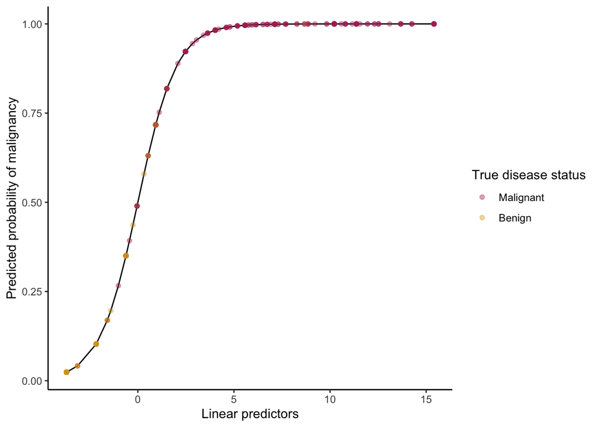

```r
# Don't forget best practices: Let's order our legend.
ggplot(logistic_model_plot_data) +
  aes(x = logistic_x,
      y = logistic_y) +
  geom_line() +
  geom_point(aes(color = fct_relevel(truth, "Malignant", "Benign")),
             alpha = 0.4) +
  scale_color_manual(values = c("maroon", "goldenrod")) +
  labs(x = "Linear predictors",
       y = "Predicted probability of malignancy",
       color = "True disease status")
```

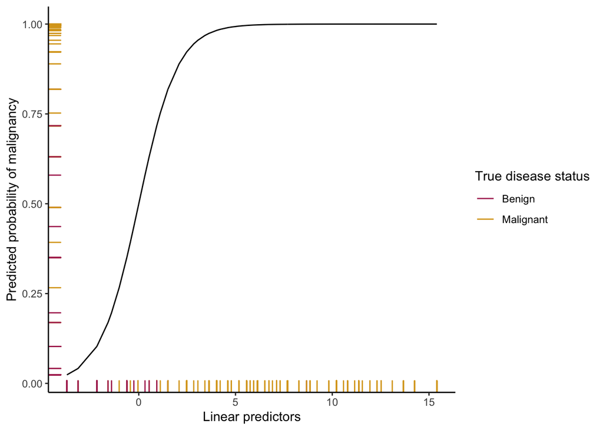

```r
# DO YOU PREFER A RUG???? DO THAT INSTEAD!!!!!! TOTALLY ALLOWED ON HW11 FOR THIS QUESTION!!!!!!!
ggplot(logistic_model_plot_data) +
  aes(x = logistic_x,
      y = logistic_y) +
  geom_line() +
  geom_rug(aes(color = truth)) + # alpha trial/error here
  # feeling fancy :)
  scale_color_manual(values = c("maroon", "goldenrod")) +
  labs(x = "Linear predictors",
       y = "Predicted probability of malignancy",
       color = "True disease status")
```

### Part 5: Performance at a given threshold

```r
# Step 1: Define the threshold
sucess_threshold <- 0.85

# Step 2: Collect model results *and truth* into a usable tibble
results_and_truths <- tibble(
  truth = biopsy$outcome,
  model_prob_success = candidate2$fitted.values
)

# Step 2 (or combine with last step if you want! slowly here for notes and learning): Determine model predictions
results_and_truths %>%
  mutate(model_result = if_else(model_prob_success >=sucess_threshold,
                                "malignant",
                                "benign")) %>%
  select(-model_prob_success)  %>%
  # Is each row FP, TP, FN, TN??? COMMENTS ARE SO HELPFUL!!!!!!!!!!!!!!!!!!!
  ##################################################
  mutate(result_type = case_when(
            # positive truth and positive result: TP
            truth == "malignant" & model_result == "malignant" ~ "TP",
            # positive truth and negative result: FN
            truth == "malignant" & model_result == "benign" ~ "FN",
            # negative truth and positive result: FP
            truth == "benign" & model_result == "malignant" ~ "FP",
            # negative truth and negative result: TP
            truth == "benign" & model_result == "benign" ~ "TN")
  ) %>%
  # Add them up!! Note that if one was missing, that means it was ****0***
  count(result_type) -> confusion_results

confusion_results
```

```
## # A tibble: 4 × 2
##   result_type     n
##   <chr>       <int>
## 1 FN             63
## 2 FP              3
## 3 TN            441
## 4 TP            176
```

```r
# Step 3: Calculate a thing! for example, accuracy.
# Accuracy = (TP + TN) / (TP + TN + FP + FN)

#### Approach #1: Use R as a calculator
(441 + 176) / (63+3+441+176)
```

```
## [1] 0.9033675
```

```r
#### Approach #2: Use the tidyverse and avoid all hardcoding (SAFER!!!)
confusion_results %>%
  pivot_wider(names_from = "result_type",
              values_from = "n") -> wide_confusion
wide_confusion
```

```
## # A tibble: 1 × 4
##      FN    FP    TN    TP
##   <int> <int> <int> <int>
## 1    63     3   441   176
```

```r
wide_confusion %>%
  mutate(accuracy = (TN + TP)/(TN+TP+FN+FP))
```

```
## # A tibble: 1 × 5
##      FN    FP    TN    TP accuracy
##   <int> <int> <int> <int>    <dbl>
## 1    63     3   441   176    0.903
```

- Remember: We only want to consider *relevant predictors!*
- We have a new biopsy sample with the following values (these are Candidate Model 2’s predictors!). At a threshold of 85%, does this model predict the sample is malignant or benign?
  - `uniform_cell_size`: 5
  - `mitoses`: 3

```r
# make a tibble with new information with names exactly matching!
tibble(uniform_cell_size = 5,
       mitoses = 3) -> new_data

# Predict **WITH ARGUMENT type = "response"** OR ELSE IT WONT WORK CORRECTLY, EVEN THOUGH IT LOOKS LIKE IT WORKS!!!!!
predict(candidate2, new_data, type = "response")
```

```
##         1
## 0.9742025
```

According to our model, There is a 97.4% chance this new biopsy sample is malignant. This is larger than the threshold of 85%, so we conclude YES the model thinks this is a malignant sample. **The logistic regression CLASSIFIES this sample as malignant at an 85% threshold.**